# Test a Perceptual Phenomenon

### Analyzing the Stroop Effect

Perform the analysis in the space below. Remember to follow [the instructions](https://docs.google.com/document/d/1-OkpZLjG_kX9J6LIQ5IltsqMzVWjh36QpnP2RYpVdPU/pub?embedded=True) and review the [project rubric](https://review.udacity.com/#!/rubrics/71/view) before submitting. Once you've completed the analysis and write up, download this file as a PDF or HTML file and submit in the next section.

(1) What is the independent variable? What is the dependent variable?

Independent Variable: The two task conditions.

Dependent Variable: Time taken to complete each task.

(2) What is an appropriate set of hypotheses for this task? What kind of statistical test do you expect to perform? Justify your choices.

Null Hypothesis: The time taken to complete both the tasks are equal.

Ho: μ1=μ2., where Ho is Null Hypothesis and μ1 and μ2 are population mean of Congruent and Incongruent words condition tasks respectively.

Alternative Hypothesis: The time taken to complete both the task are not equal.

Ha: μ1≠μ2., where Ha is Alternative Hypothesis and μ1 and μ2 are population mean of Congruent and Incongruent words condition tasks respectively.

Since we don't know the population standaed deviation and the size of the samples is less than 30, we cannot perform z-test on the means. So, we are performing a t-test. The t-test we are going to perform is a paired t-test. This test is performed because of the fact that both the tasks are performed by same candidate. It would tests whether the mean of the differences between dependent or paired observations is equal to a target value.

The main intention of Stroop effect task is to determine whether the people can complete both tasks at the same time. That is what I intend to find from the given dataset.

(3) Report some descriptive statistics regarding this dataset. Include at least one measure of central tendency and at least one measure of variability. The name of the data file is 'stroopdata.csv'.

```python
# Perform the analysis here
import pandas as pd
import scipy.stats as stats

data = pd.read_csv('stroopdata.csv')

congruent = data['Congruent'].values.tolist()
incongruent = data['Incongruent'].values.tolist()

data_desc = data.describe()
data_medaian =  data.median()
data_variance = data.var()

print ('General Description')
print (data_desc)
print ('\n')

print ('Median')
print (data_medaian)
print ('\n')

print ('Variance')
print (data_variance)
```

```
General Description
       Congruent  Incongruent
count  24.000000    24.000000
mean   14.051125    22.015917
std     3.559358     4.797057
min     8.630000    15.687000
25%    11.895250    18.716750
50%    14.356500    21.017500
75%    16.200750    24.051500
max    22.328000    35.255000


Median
Congruent      14.3565
Incongruent    21.0175
dtype: float64


Variance
Congruent      12.669029
Incongruent    23.011757
dtype: float64
```

1.Congruent

Mean: 14.051125

Median: 14.3565

Variance: 12.669029

Standard Deviation: 3.559358

2.Incongruent

Mean: 22.015917

Median: 21.0175

Variance: 23.011757

Standard Deviation: 4.797057

(4) Provide one or two visualizations that show the distribution of the sample data. Write one or two sentences noting what you observe about the plot or plots.

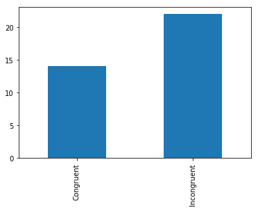

```python
# Build the visualizations here

%matplotlib inline

data.mean().plot('bar')
```

The bar chart of mean of the samples clearly states that the time taken to complete the incongruent words condition task is more than the time taken to complete the congruent words condition task. It is evident from here that our alternative hypothesis is right. But, we must not arrive to conculsion before performing t-test.

(5) Now, perform the statistical test and report the results. What is the confidence level and your critical statistic value? Do you reject the null hypothesis or fail to reject it? Come to a conclusion in terms of the experiment task. Did the results match up with your expectations?

```python
# Perform the statistical test here

stats.ttest_rel(congruent, incongruent)
```

```
Ttest_relResult(statistic=-8.020706944109957, pvalue=4.1030005857111781e-08)
```

The given samples are related. Both the tasks are performed by the same person and that is why we are performing a t-test on related sample. Since our null hypothesis states that time taken to complete both the tasks are equal, we must perform a two-tailed t-test.

Confidence level: 95%

t-critical value: ±2.069

t-statistical value: -8.020706944109957

p-value: 4.1030005857111781e-08

The t-statistical value is much lower than the t-critical value.

Therefore, we reject the Null Hypothesis.

This states that the time taken to complete Incongruent words condition task is much greater than the time taken to complete Congruent words condition task.

The result we obtained is exactly what we predicted from the bar chart. So, this is not much of a surprise.

The reason why we came to this conclusion is pretty simple. Of course, it is tough for people to perform Incongruent words condition task. Our brain definitely takes time to process the color and make us say it out loud instead of the word written. The result has been all over from the very beginning when we calculated the central tendency.

References:

1. http://www.statisticshowto.com/when-to-use-a-t-score-vs-z-score/
2. http://support.minitab.com/en-us/minitab/17/topic-library/basic-statistics-and-graphs/hypothesis-tests/tests-of-means/types-of-t-tests/
3. https://docs.scipy.org/doc/scipy-0.15.1/reference/generated/scipy.stats.ttest_rel.html